# R Notebook

# Dáta

Dáta v súbore *Osipane.txt* predstavujú počet porazených ošípaných vo Victorii (Austrália) za obdobie január 1985 - August 1995 zaznamenávaných mesačne.

# Zadanie

Nájdite model pre daný časový rad a urobte predikciu pre nasledujúce 3 obdobia. Každý výsledok, resp. krok vašej analýzy stručne okomentujte a interpretujte.

# Načítanie a vykreslenie dát

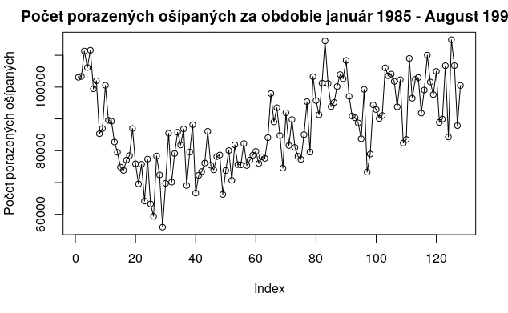

```r
Osipane <- read.table("Osipane.txt", quote="\"", comment.char="")
data = Osipane$V1
plot(data, main = 'Počet porazených ošípaných za obdobie január 1985 - August 1995', ylab = 'Počet porazených ošípaných', type ='o')
```

# Popis dát

- vidíme trend - kvadratický?
- variabilita sa zdá byť ustálená
- zrejme bez sezónnej a periodickej zložky
- rad nebude stacionárny

# Fitovanie kvadratickou funkciou

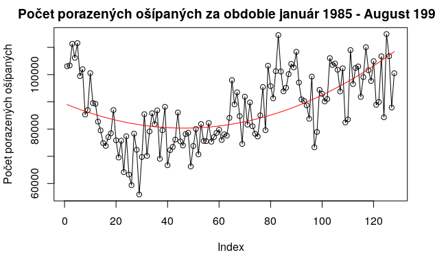

```r
t = 1:length(data)
t2 = t*t
lmData2 = lm(data~t+t2)
plot(data, main = 'Počet porazených ošípaných za obdobie január 1985 - August 1995', ylab = 'Počet porazených ošípaných', type ='o')
lines(t, predict(lmData2), col='red')
```

```r
show(lmData2)
```

```
Call:
lm(formula = data ~ t + t2)

Coefficients:
(Intercept)            t           t2
  89381.325     -390.311        4.214
```

# Reziduá

[figure not shown]

```r
resLm2 = residuals(lmData2)
plot(resLm2, main = 'Reziduá po fite kubickou funkciou',type='o')
```

Fit kvadratickou funkciou v istých oblastiach nekopíruje správanie dáta veľmi dobre a reziduá nedávajú stacionárny rad. Skúsime kubickú funkciou.

# Fitovanie kubickou funkciou

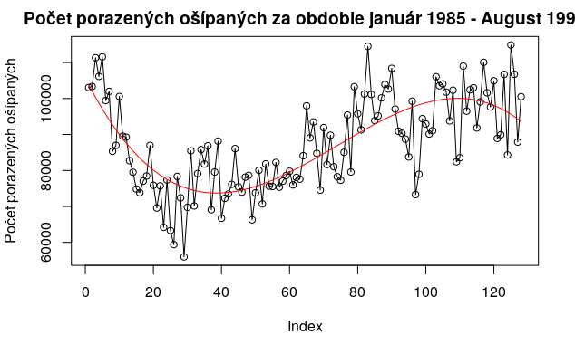

```r
t = 1:length(data)
t2 = t*t
t3 = t2*t
lmData3 = lm(data~t+t2+t3)
plot(data, main = 'Počet porazených ošípaných za obdobie január 1985 - August 1995', ylab = 'Počet porazených ošípaných', type ='o')
lines(t, predict(lmData3), col='red')
```

```r
summary(lmData3)
```

```
Call:
lm(formula = data ~ t + t2 + t3)

Residuals:
     Min       1Q   Median       3Q      Max
-24639.4  -5512.6     49.4   6166.8  22699.1

Coefficients:
              Estimate Std. Error t value Pr(>|t|)
(Intercept)  1.057e+05  3.131e+03  33.754  < 2e-16 ***
t           -1.879e+03  2.094e+02  -8.975 3.75e-15 ***
t2           3.296e+01  3.764e+00   8.757 1.24e-14 ***
t3          -1.486e-01  1.919e-02  -7.744 2.95e-12 ***
---
Signif. codes:  0 ‘***’ 0.001 ‘**’ 0.01 ‘*’ 0.05 ‘.’ 0.1 ‘ ’ 1

Residual standard error: 8599 on 124 degrees of freedom
Multiple R-squared:  0.5653,    Adjusted R-squared:  0.5548
F-statistic: 53.76 on 3 and 124 DF,  p-value: < 2.2e-16
```

Kubická funkcia dáva lepší fit.